# ABCDv5.1 Y2 Scores

# Elastic net linear regression using ‘glmnet’

80-20 training-test split. Training sample N=4601, test sample N=1176. Although glmnet standardises data by default, coefficients are returned on their original scales. To get standardised coefficients for applying to other data, I’m scaling the raw data before inputting to glmnet.

## CBCL DSM5-oriented depression subscale

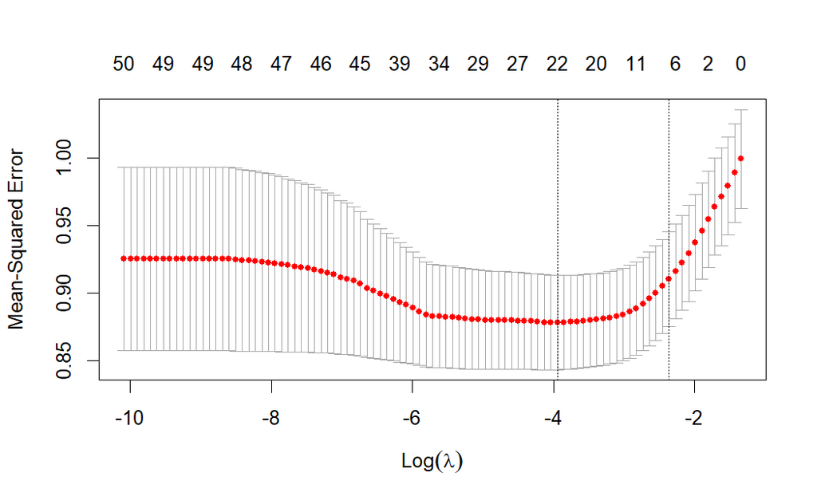

|  | Lambda | Index | Measure | SE | Nonzero |
| --- | --- | --- | --- | --- | --- |
| min | 0.019 | 29 | 0.878 | 0.035 | 22 |
| 1se | 0.094 | 12 | 0.910 | 0.035 | 7 |

### Fit statistics

| sample | lambda | mse | mae |
| --- | --- | --- | --- |
| training | min | 0.857 | 0.659 |
| training | 1se | 0.906 | 0.679 |
| test | min | 0.842 | 0.636 |
| test | 1se | 0.842 | 0.636 |

### Plot predictions

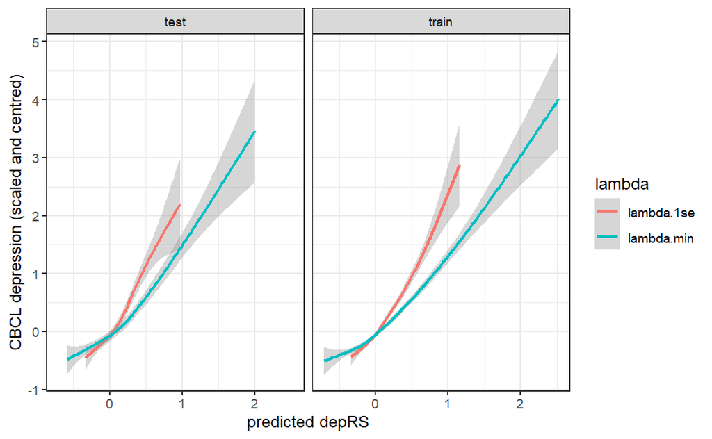

## CBCL internalising subscale

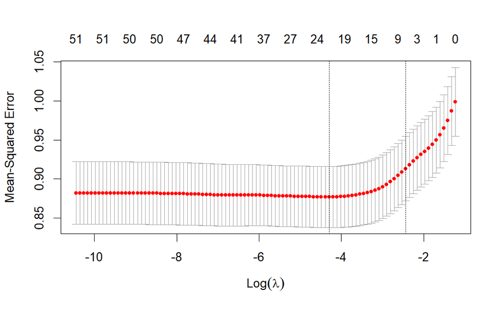

|  | Lambda | Index | Measure | SE | Nonzero |
| --- | --- | --- | --- | --- | --- |
| min | 0.014 | 34 | 0.877 | 0.039 | 22 |
| 1se | 0.087 | 14 | 0.913 | 0.041 | 7 |

### Fit statistics

| sample | lambda | mse | mae |
| --- | --- | --- | --- |
| training | min | 0.860 | 0.671 |
| training | 1se | 0.908 | 0.692 |
| test | min | 0.844 | 0.635 |
| test | 1se | 0.844 | 0.635 |

### Plot predictions

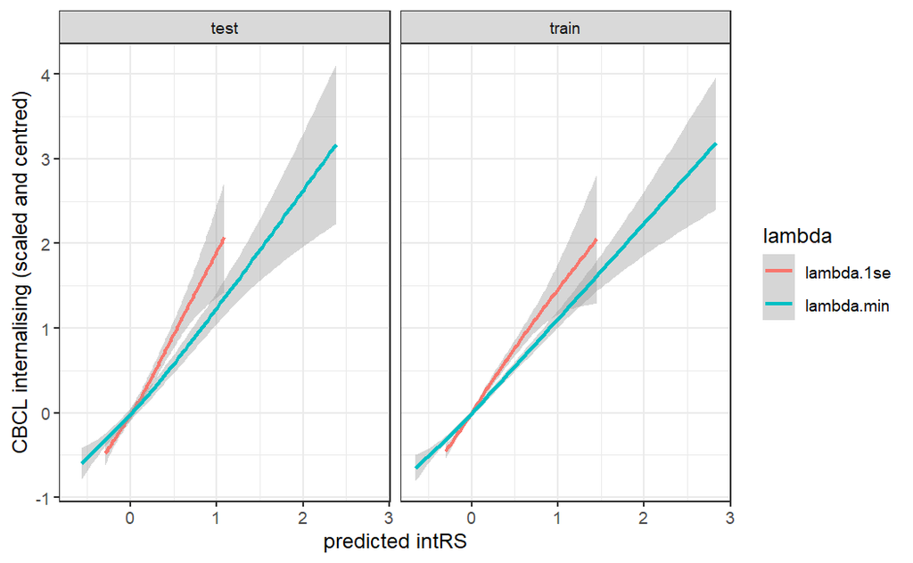

## Coefficients

beta.min = coefficients for lambda value that produces minimum mean cross-validated error.

beta.1se = coefficients for lambda value that produces the most regularized model while keeping the cross-validated error within one standard error of the minimum.

| predictor | dep_beta.min | dep_beta.1se | int_beta.min | int_beta.1se |
| --- | --- | --- | --- | --- |
| (Intercept) | -1.852 | -0.219 | -1.908 | -0.201 |
| tlfb_use_days | 0.018 | 0.000 | 0.015 | 0.000 |
| weightcontrol_ksads | 0.348 | 0.040 | 0.297 | 0.010 |
| witness_comm_violence | 0.000 | 0.000 | 0.000 | 0.000 |
| death_loved_one | 0.000 | 0.000 | 0.028 | 0.000 |
| witness_dv | 0.016 | 0.000 | 0.079 | 0.000 |
| s_abuse | 0.414 | 0.000 | 0.676 | 0.168 |
| p_abuse | 0.392 | 0.000 | 0.457 | 0.000 |
| emot_abuse | 0.176 | 0.000 | 0.030 | 0.000 |
| serious_accident | 0.049 | 0.000 | 0.079 | 0.000 |
| bkfs_fruit | -0.011 | 0.000 | -0.001 | 0.000 |
| bkfs_veg | -0.013 | 0.000 | 0.000 | 0.000 |
| sleep_hrs | 0.148 | 0.091 | 0.000 | 0.000 |
| bmi | 0.000 | 0.000 | 0.022 | 0.000 |
| needed_food | 0.131 | 0.000 | 0.112 | 0.000 |
| income | 0.000 | 0.000 | 0.000 | 0.000 |
| parent_ed | 0.000 | 0.000 | 0.000 | 0.000 |
| gender | 0.000 | 0.000 | 0.000 | 0.000 |
| comm_safety | -0.006 | 0.000 | -0.037 | 0.000 |
| discrimination | 0.000 | 0.000 | 0.000 | 0.000 |
| days_active | -0.016 | 0.000 | -0.006 | 0.000 |
| bully_relational | 0.055 | 0.010 | 0.053 | 0.009 |
| bully_reputational | 0.041 | 0.030 | 0.038 | 0.035 |
| bully_overt | 0.000 | 0.000 | 0.000 | 0.000 |
| chronotype | 0.000 | 0.000 | 0.000 | 0.000 |
| life_events | 0.153 | 0.131 | 0.199 | 0.182 |
| agemths | 0.000 | 0.000 | 0.000 | 0.000 |
| tlfb_use_days_gender | 0.000 | 0.000 | 0.000 | 0.000 |
| weightcontrol_ksads_gender | 0.000 | 0.000 | 0.000 | 0.000 |
| witness_comm_violence_gender | 0.000 | 0.000 | 0.000 | 0.000 |
| death_loved_one_gender | 0.000 | 0.000 | 0.000 | 0.000 |
| witness_dv_gender | 0.000 | 0.000 | 0.000 | 0.000 |
| s_abuse_gender | 0.000 | 0.000 | 0.000 | 0.000 |
| p_abuse_gender | 0.000 | 0.000 | 0.000 | 0.000 |
| emot_abuse_gender | 0.000 | 0.000 | 0.000 | 0.000 |
| serious_accident_gender | 0.000 | 0.000 | 0.000 | 0.000 |
| bkfs_fruit_gender | 0.000 | 0.000 | 0.000 | 0.000 |
| bkfs_veg_gender | 0.000 | 0.000 | 0.000 | 0.000 |
| sleep_hrs_gender | 0.000 | 0.000 | 0.036 | 0.007 |
| bmi_gender | 0.008 | 0.000 | 0.000 | 0.000 |
| needed_food_gender | 0.000 | 0.000 | 0.000 | 0.000 |
| income_gender | 0.000 | 0.000 | 0.000 | 0.000 |
| parent_ed_gender | 0.000 | 0.000 | 0.000 | 0.000 |
| comm_safety_gender | 0.000 | 0.000 | 0.000 | 0.000 |
| discrimination_gender | 0.000 | 0.000 | 0.000 | 0.000 |
| days_active_gender | -0.020 | 0.000 | -0.024 | 0.000 |
| bully_relational_gender | 0.000 | 0.000 | 0.000 | 0.000 |
| bully_reputational_gender | 0.000 | 0.000 | 0.000 | 0.000 |
| bully_overt_gender | 0.036 | 0.012 | 0.028 | 0.000 |
| chronotype_gender | 0.000 | 0.000 | 0.000 | 0.000 |
| life_events_gender | 0.030 | 0.018 | 0.022 | 0.011 |
| agemths_gender | 0.008 | 0.000 | 0.005 | 0.000 |

### beta.min

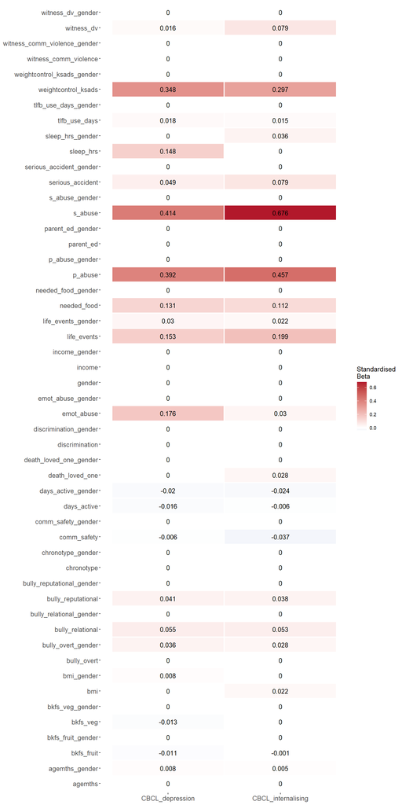

### beta.1se

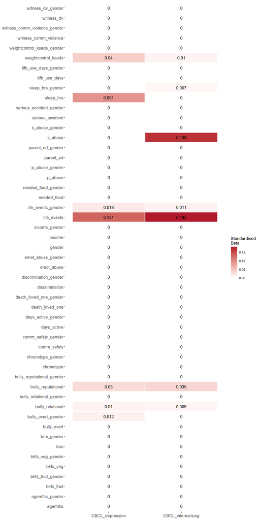

## Non-zero coefficients

### beta.min

|  | preds | beta.min | beta.1se | out |
| --- | --- | --- | --- | --- |
| 7 | s_abuse | 0.6763385 | 0.1684763 | CBCL_internalising |
| 8 | p_abuse | 0.4574680 | 0.0000000 | CBCL_internalising |
| 71 | s_abuse | 0.4140060 | 0.0000000 | CBCL_depression |
| 81 | p_abuse | 0.3924286 | 0.0000000 | CBCL_depression |
| 310 | weightcontrol_ksads | 0.3484005 | 0.0403982 | CBCL_depression |
| 3 | weightcontrol_ksads | 0.2974709 | 0.0096664 | CBCL_internalising |
| 26 | life_events | 0.1988317 | 0.1817377 | CBCL_internalising |
| 91 | emot_abuse | 0.1759225 | 0.0000000 | CBCL_depression |
| 261 | life_events | 0.1527302 | 0.1308346 | CBCL_depression |
| 131 | sleep_hrs | 0.1478673 | 0.0907223 | CBCL_depression |
| 151 | needed_food | 0.1311860 | 0.0000000 | CBCL_depression |
| 15 | needed_food | 0.1116313 | 0.0000000 | CBCL_internalising |
| 10 | serious_accident | 0.0791736 | 0.0000000 | CBCL_internalising |
| 6 | witness_dv | 0.0787623 | 0.0000000 | CBCL_internalising |
| 221 | bully_relational | 0.0549432 | 0.0103273 | CBCL_depression |
| 22 | bully_relational | 0.0525839 | 0.0086939 | CBCL_internalising |
| 101 | serious_accident | 0.0490606 | 0.0000000 | CBCL_depression |
| 231 | bully_reputational | 0.0413078 | 0.0301278 | CBCL_depression |
| 23 | bully_reputational | 0.0379585 | 0.0345468 | CBCL_internalising |
| 491 | bully_overt_gender | 0.0360287 | 0.0124007 | CBCL_depression |
| 39 | sleep_hrs_gender | 0.0358602 | 0.0069793 | CBCL_internalising |
| 9 | emot_abuse | 0.0302412 | 0.0000000 | CBCL_internalising |
| 511 | life_events_gender | 0.0299437 | 0.0178453 | CBCL_depression |
| 49 | bully_overt_gender | 0.0279371 | 0.0000000 | CBCL_internalising |
| 5 | death_loved_one | 0.0275214 | 0.0000000 | CBCL_internalising |
| 14 | bmi | 0.0220101 | 0.0000000 | CBCL_internalising |
| 51 | life_events_gender | 0.0216874 | 0.0110687 | CBCL_internalising |
| 210 | tlfb_use_days | 0.0179539 | 0.0000000 | CBCL_depression |
| 61 | witness_dv | 0.0164661 | 0.0000000 | CBCL_depression |
| 2 | tlfb_use_days | 0.0154475 | 0.0000000 | CBCL_internalising |
| 521 | agemths_gender | 0.0083700 | 0.0000000 | CBCL_depression |
| 401 | bmi_gender | 0.0080808 | 0.0000000 | CBCL_depression |
| 52 | agemths_gender | 0.0052878 | 0.0000000 | CBCL_internalising |
| 11 | bkfs_fruit | -0.0011292 | 0.0000000 | CBCL_internalising |
| 191 | comm_safety | -0.0058760 | 0.0000000 | CBCL_depression |
| 21 | days_active | -0.0059645 | 0.0000000 | CBCL_internalising |
| 111 | bkfs_fruit | -0.0111852 | 0.0000000 | CBCL_depression |
| 121 | bkfs_veg | -0.0133317 | 0.0000000 | CBCL_depression |
| 211 | days_active | -0.0164052 | 0.0000000 | CBCL_depression |
| 461 | days_active_gender | -0.0196999 | 0.0000000 | CBCL_depression |
| 46 | days_active_gender | -0.0238066 | 0.0000000 | CBCL_internalising |
| 19 | comm_safety | -0.0365540 | 0.0000000 | CBCL_internalising |

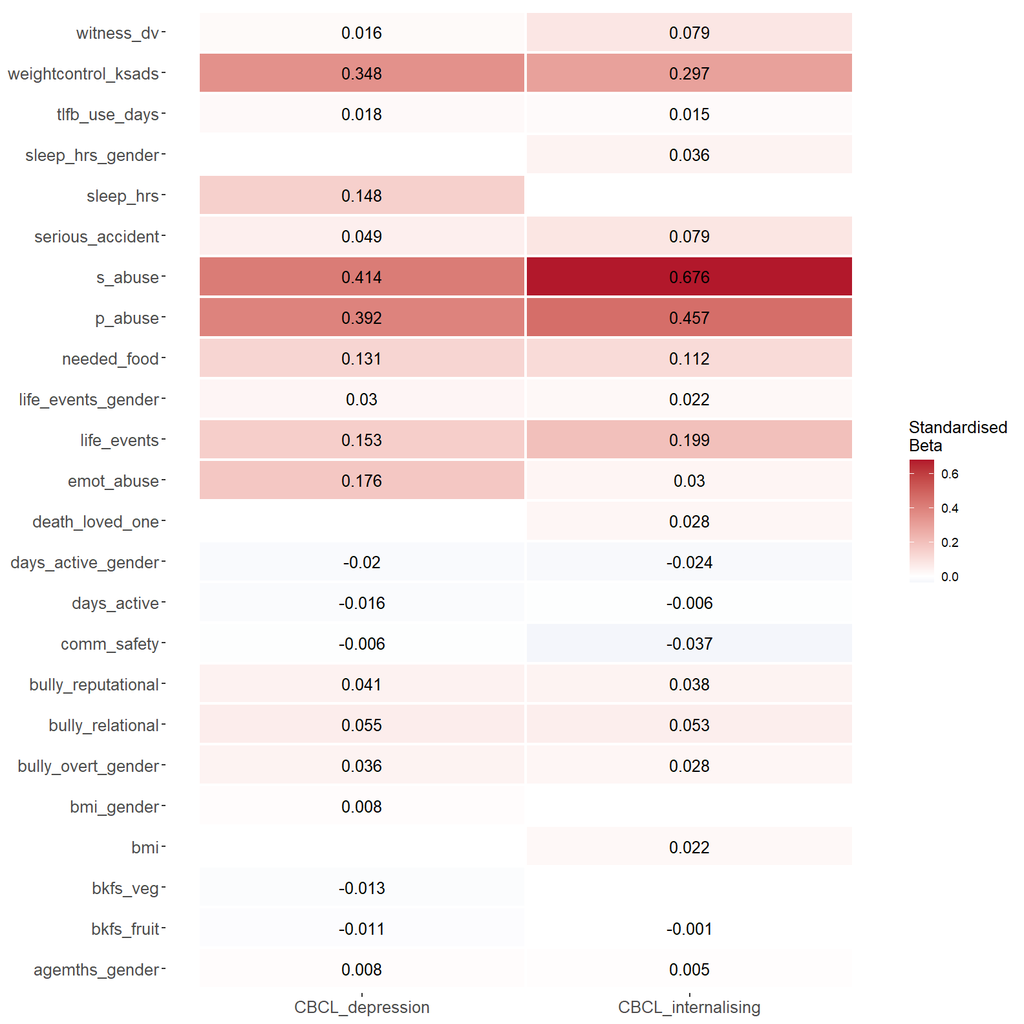

### beta.min > 0.01

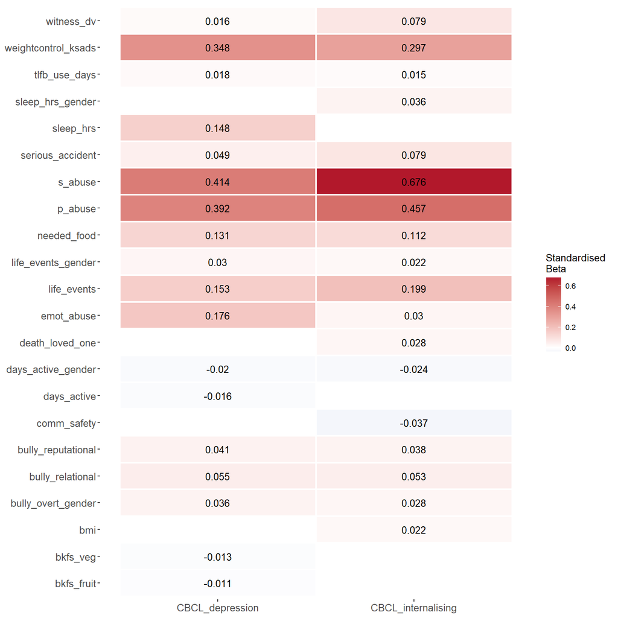

### beta.1se

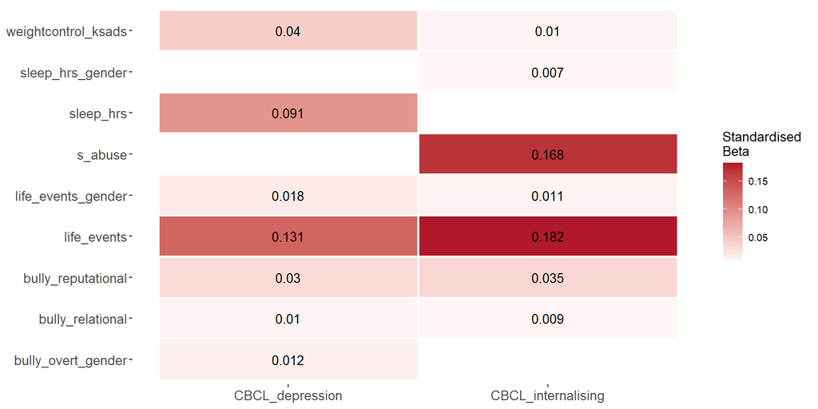

[figure not shown]

## Correlation plots

### Whole sample

NULL

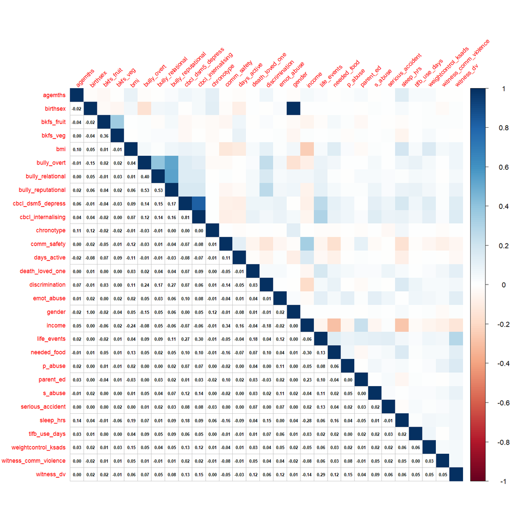

### Training sample

NULL

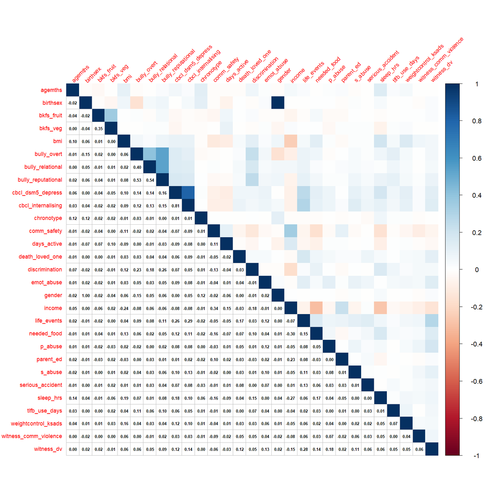

### Test sample

NULL

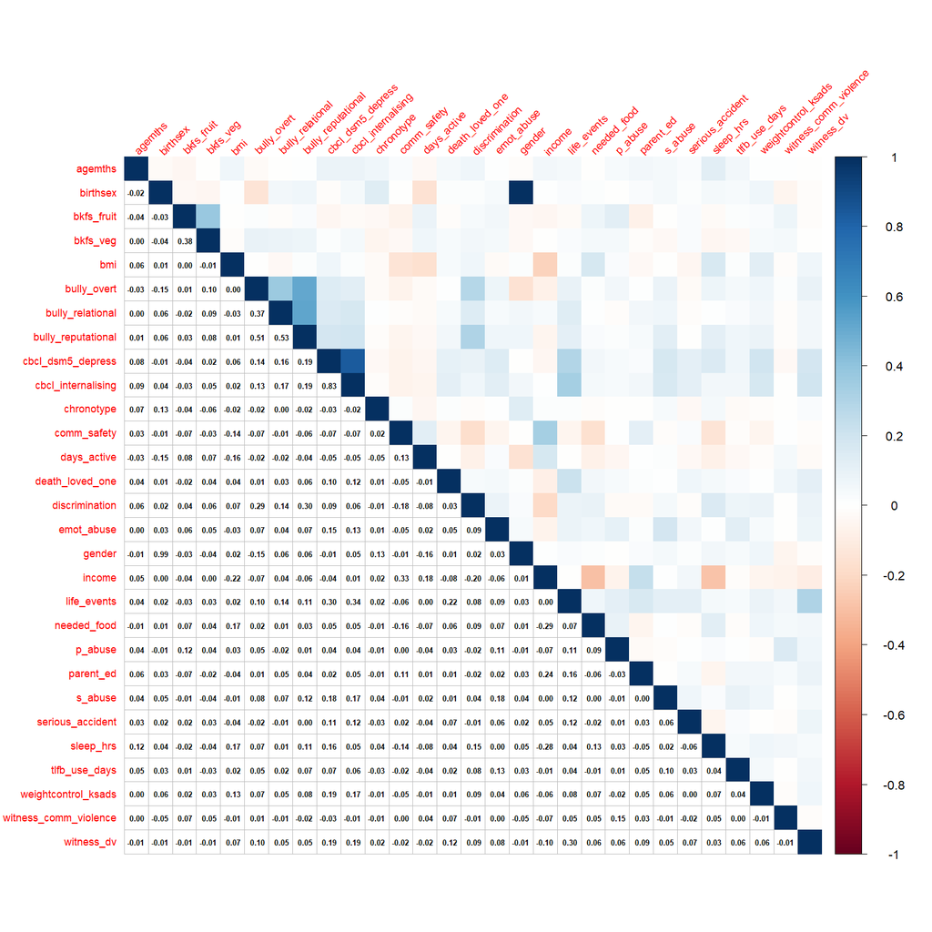

## Descriptives

### Data Frame Summary

**Dimensions:** 5777 x 30  
**Duplicates:** 0

| Variable | Stats / Values | Freqs (% of Valid) |
| --- | --- | --- |
| tlfb_use_days [integer] | Mean (sd) : 0.031 (0.648) min < med < max: 0 < 0 < 26 IQR (CV) : 0 (20.914) | 13 distinct values |
| weightcontrol_ksads [factor] | 1. 0 2. 1 | 5556 (96.2%) 221 ( 3.8%) |
| witness_comm_violence [factor] | 1. 0 2. 1 | 5741 (99.4%) 36 ( 0.6%) |
| death_loved_one [factor] | 1. 0 2. 1 | 4458 (77.2%) 1319 (22.8%) |
| witness_dv [factor] | 1. 0 2. 1 | 5465 (94.6%) 312 ( 5.4%) |
| s_abuse [factor] | 1. 0 2. 1 | 5702 (98.7%) 75 ( 1.3%) |
| p_abuse [factor] | 1. 0 2. 1 | 5746 (99.5%) 31 ( 0.5%) |
| emot_abuse [factor] | 1. 0 2. 1 | 5720 (99.0%) 57 ( 1.0%) |
| serious_accident [factor] | 1. 0 2. 1 | 5303 (91.8%) 474 ( 8.2%) |
| bkfs_fruit [numeric] | Mean (sd) : 1.235 (0.829) min < med < max: 0 < 1.09 < 6.29 IQR (CV) : 1.022 (0.672) | 1306 distinct values |
| bkfs_veg [numeric] | Mean (sd) : 0.69 (0.408) min < med < max: 0 < 0.619 < 3.74 IQR (CV) : 0.507 (0.591) | 1114 distinct values |
| sleep_hrs [ordered, factor] | 1. 9+hrs 2. 8-9hrs 3. 7-8hrs 4. 5-7hrs 5. <5hrs | 1883 (32.6%) 2552 (44.2%) 1035 (17.9%) 290 ( 5.0%) 17 ( 0.3%) |
| bmi [numeric] | Mean (sd) : 20.651 (4.922) min < med < max: 9.066 < 19.386 < 51.454 IQR (CV) : 5.663 (0.238) | 4433 distinct values |
| needed_food [factor] | 1. 0 2. 1 | 5424 (93.9%) 353 ( 6.1%) |
| income [integer] | Mean (sd) : 7.628 (2.232) min < med < max: 1 < 8 < 10 IQR (CV) : 2 (0.293) | 1 : 152 ( 2.6%) 2 : 143 ( 2.5%) 3 : 127 ( 2.2%) 4 : 196 ( 3.4%) 5 : 315 ( 5.5%) 6 : 409 ( 7.1%) 7 : 765 (13.2%) 8 : 804 (13.9%) 9 : 2013 (34.8%) 10 : 853 (14.8%) |
| parent_ed [ordered, factor] | 1. <HS 2. HS/GED 3. Some_College 4. Bachelor 5. Postgrad | 264 ( 4.6%) 502 ( 8.7%) 3760 (65.1%) 193 ( 3.3%) 1058 (18.3%) |
| birthsex [factor] | 1. M 2. F 3. Intersex | 3111 (53.9%) 2666 (46.1%) 0 ( 0.0%) |
| gender [factor] | 1. M 2. F 3. GNC | 3109 (53.8%) 2665 (46.1%) 3 ( 0.1%) |
| race_ethnicity [factor] | 1. White 2. Black 3. Hispanic 4. Asian 5. Other | 3334 (57.7%) 663 (11.5%) 1082 (18.7%) 132 ( 2.3%) 566 ( 9.8%) |
| comm_safety [numeric] | Mean (sd) : 3.902 (0.911) min < med < max: 1 < 4 < 5 IQR (CV) : 1.333 (0.234) | 15 distinct values |
| discrimination [numeric] | Mean (sd) : 1.126 (0.309) min < med < max: 1 < 1 < 5 IQR (CV) : 0.143 (0.275) | 45 distinct values |
| days_active [integer] | Mean (sd) : 3.845 (2.118) min < med < max: 0 < 4 < 7 IQR (CV) : 3 (0.551) | 0 : 456 ( 7.9%) 1 : 408 ( 7.1%) 2 : 781 (13.5%) 3 : 950 (16.4%) 4 : 802 (13.9%) 5 : 978 (16.9%) 6 : 520 ( 9.0%) 7 : 882 (15.3%) |
| bully_relational [integer] | Mean (sd) : 4.797 (1.912) min < med < max: 3 < 4 < 15 IQR (CV) : 3 (0.398) | 13 distinct values |
| bully_reputational [integer] | Mean (sd) : 3.98 (1.818) min < med < max: 3 < 3 < 15 IQR (CV) : 1 (0.457) | 13 distinct values |
| bully_overt [integer] | Mean (sd) : 3.658 (1.375) min < med < max: 3 < 3 < 15 IQR (CV) : 1 (0.376) | 13 distinct values |
| chronotype [numeric] | Mean (sd) : 19.7 (11.473) min < med < max: 0.004 < 26.703 < 41.985 IQR (CV) : 23.304 (0.582) | 4149 distinct values |
| life_events [integer] | Mean (sd) : 3.383 (2.641) min < med < max: 0 < 3 < 18 IQR (CV) : 4 (0.781) | 19 distinct values |
| agemths [integer] | Mean (sd) : 143.492 (7.793) min < med < max: 127 < 143 < 166 IQR (CV) : 13 (0.054) | 40 distinct values |
| cbcl_internalising [integer] | Mean (sd) : 4.957 (5.53) min < med < max: 0 < 3 < 50 IQR (CV) : 6 (1.116) | 42 distinct values |
| cbcl_dsm5_depress [integer] | Mean (sd) : 1.489 (2.235) min < med < max: 0 < 1 < 22 IQR (CV) : 2 (1.501) | 19 distinct values |

### Data Frame Summary

#### train

**Dimensions:** 4601 x 30  
**Duplicates:** 0

| Variable | Stats / Values | Freqs (% of Valid) |
| --- | --- | --- |
| tlfb_use_days [integer] | Mean (sd) : 0.027 (0.585) min < med < max: 0 < 0 < 22 IQR (CV) : 0 (22.052) | 11 distinct values |
| weightcontrol_ksads [factor] | 1. 0 2. 1 | 4422 (96.1%) 179 ( 3.9%) |
| witness_comm_violence [factor] | 1. 0 2. 1 | 4569 (99.3%) 32 ( 0.7%) |
| death_loved_one [factor] | 1. 0 2. 1 | 3575 (77.7%) 1026 (22.3%) |
| witness_dv [factor] | 1. 0 2. 1 | 4348 (94.5%) 253 ( 5.5%) |
| s_abuse [factor] | 1. 0 2. 1 | 4540 (98.7%) 61 ( 1.3%) |
| p_abuse [factor] | 1. 0 2. 1 | 4580 (99.5%) 21 ( 0.5%) |
| emot_abuse [factor] | 1. 0 2. 1 | 4552 (98.9%) 49 ( 1.1%) |
| serious_accident [factor] | 1. 0 2. 1 | 4212 (91.5%) 389 ( 8.5%) |
| bkfs_fruit [numeric] | Mean (sd) : 1.23 (0.837) min < med < max: 0 < 1.08 < 6.29 IQR (CV) : 1.023 (0.681) | 1225 distinct values |
| bkfs_veg [numeric] | Mean (sd) : 0.691 (0.414) min < med < max: 0 < 0.62 < 3.74 IQR (CV) : 0.515 (0.599) | 1075 distinct values |
| sleep_hrs [ordered, factor] | 1. 9+hrs 2. 8-9hrs 3. 7-8hrs 4. 5-7hrs 5. <5hrs | 1486 (32.3%) 2051 (44.6%) 825 (17.9%) 224 ( 4.9%) 15 ( 0.3%) |
| bmi [numeric] | Mean (sd) : 20.65 (4.936) min < med < max: 9.066 < 19.374 < 51.454 IQR (CV) : 5.677 (0.239) | 3667 distinct values |
| needed_food [factor] | 1. 0 2. 1 | 4320 (93.9%) 281 ( 6.1%) |
| income [integer] | Mean (sd) : 7.636 (2.234) min < med < max: 1 < 8 < 10 IQR (CV) : 2 (0.293) | 1 : 122 ( 2.7%) 2 : 116 ( 2.5%) 3 : 102 ( 2.2%) 4 : 153 ( 3.3%) 5 : 242 ( 5.3%) 6 : 329 ( 7.2%) 7 : 596 (13.0%) 8 : 641 (13.9%) 9 : 1625 (35.3%) 10 : 675 (14.7%) |
| parent_ed [ordered, factor] | 1. <HS 2. HS/GED 3. Some_College 4. Bachelor 5. Postgrad | 203 ( 4.4%) 390 ( 8.5%) 3001 (65.2%) 159 ( 3.5%) 848 (18.4%) |
| birthsex [factor] | 1. M 2. F 3. Intersex | 2450 (53.2%) 2151 (46.8%) 0 ( 0.0%) |
| gender [factor] | 1. M 2. F 3. GNC | 2448 (53.2%) 2151 (46.8%) 2 ( 0.0%) |
| race_ethnicity [factor] | 1. White 2. Black 3. Hispanic 4. Asian 5. Other | 2686 (58.4%) 534 (11.6%) 838 (18.2%) 104 ( 2.3%) 439 ( 9.5%) |
| comm_safety [numeric] | Mean (sd) : 3.908 (0.911) min < med < max: 1 < 4 < 5 IQR (CV) : 1.333 (0.233) | 15 distinct values |
| discrimination [numeric] | Mean (sd) : 1.121 (0.301) min < med < max: 1 < 1 < 5 IQR (CV) : 0.143 (0.268) | 43 distinct values |
| days_active [integer] | Mean (sd) : 3.825 (2.124) min < med < max: 0 < 4 < 7 IQR (CV) : 3 (0.555) | 0 : 378 ( 8.2%) 1 : 329 ( 7.2%) 2 : 625 (13.6%) 3 : 741 (16.1%) 4 : 633 (13.8%) 5 : 796 (17.3%) 6 : 407 ( 8.8%) 7 : 692 (15.0%) |
| bully_relational [integer] | Mean (sd) : 4.787 (1.907) min < med < max: 3 < 4 < 15 IQR (CV) : 3 (0.398) | 13 distinct values |
| bully_reputational [integer] | Mean (sd) : 3.971 (1.801) min < med < max: 3 < 3 < 15 IQR (CV) : 1 (0.454) | 13 distinct values |
| bully_overt [integer] | Mean (sd) : 3.656 (1.361) min < med < max: 3 < 3 < 15 IQR (CV) : 1 (0.372) | 13 distinct values |
| chronotype [numeric] | Mean (sd) : 19.616 (11.485) min < med < max: 0.004 < 26.697 < 41.985 IQR (CV) : 23.283 (0.586) | 3428 distinct values |
| life_events [integer] | Mean (sd) : 3.388 (2.643) min < med < max: 0 < 3 < 18 IQR (CV) : 4 (0.78) | 19 distinct values |
| agemths [integer] | Mean (sd) : 143.428 (7.808) min < med < max: 127 < 143 < 166 IQR (CV) : 13 (0.054) | 40 distinct values |
| cbcl_internalising [integer] | Mean (sd) : 4.948 (5.452) min < med < max: 0 < 3 < 43 IQR (CV) : 6 (1.102) | 40 distinct values |
| cbcl_dsm5_depress [integer] | Mean (sd) : 1.47 (2.177) min < med < max: 0 < 1 < 16 IQR (CV) : 2 (1.481) | 17 distinct values |

### Data Frame Summary

#### test

**Dimensions:** 1176 x 30  
**Duplicates:** 0

| Variable | Stats / Values | Freqs (% of Valid) |
| --- | --- | --- |
| tlfb_use_days [integer] | Mean (sd) : 0.048 (0.852) min < med < max: 0 < 0 < 26 IQR (CV) : 0 (17.571) | 0 : 1163 (98.9%) 1 : 6 ( 0.5%) 2 : 4 ( 0.3%) 6 : 1 ( 0.1%) 11 : 1 ( 0.1%) 26 : 1 ( 0.1%) |
| weightcontrol_ksads [factor] | 1. 0 2. 1 | 1134 (96.4%) 42 ( 3.6%) |
| witness_comm_violence [factor] | 1. 0 2. 1 | 1172 (99.7%) 4 ( 0.3%) |
| death_loved_one [factor] | 1. 0 2. 1 | 883 (75.1%) 293 (24.9%) |
| witness_dv [factor] | 1. 0 2. 1 | 1117 (95.0%) 59 ( 5.0%) |
| s_abuse [factor] | 1. 0 2. 1 | 1162 (98.8%) 14 ( 1.2%) |
| p_abuse [factor] | 1. 0 2. 1 | 1166 (99.1%) 10 ( 0.9%) |
| emot_abuse [factor] | 1. 0 2. 1 | 1168 (99.3%) 8 ( 0.7%) |
| serious_accident [factor] | 1. 0 2. 1 | 1091 (92.8%) 85 ( 7.2%) |
| bkfs_fruit [numeric] | Mean (sd) : 1.256 (0.798) min < med < max: 0 < 1.125 < 4.7 IQR (CV) : 1.064 (0.636) | 589 distinct values |
| bkfs_veg [numeric] | Mean (sd) : 0.687 (0.384) min < med < max: 0.016 < 0.617 < 2.65 IQR (CV) : 0.484 (0.559) | 649 distinct values |
| sleep_hrs [ordered, factor] | 1. 9+hrs 2. 8-9hrs 3. 7-8hrs 4. 5-7hrs 5. <5hrs | 397 (33.8%) 501 (42.6%) 210 (17.9%) 66 ( 5.6%) 2 ( 0.2%) |
| bmi [numeric] | Mean (sd) : 20.654 (4.869) min < med < max: 12.644 < 19.401 < 47.227 IQR (CV) : 5.615 (0.236) | 1093 distinct values |
| needed_food [factor] | 1. 0 2. 1 | 1104 (93.9%) 72 ( 6.1%) |
| income [integer] | Mean (sd) : 7.598 (2.224) min < med < max: 1 < 8 < 10 IQR (CV) : 2 (0.293) | 1 : 30 ( 2.6%) 2 : 27 ( 2.3%) 3 : 25 ( 2.1%) 4 : 43 ( 3.7%) 5 : 73 ( 6.2%) 6 : 80 ( 6.8%) 7 : 169 (14.4%) 8 : 163 (13.9%) 9 : 388 (33.0%) 10 : 178 (15.1%) |
| parent_ed [ordered, factor] | 1. <HS 2. HS/GED 3. Some_College 4. Bachelor 5. Postgrad | 61 ( 5.2%) 112 ( 9.5%) 759 (64.5%) 34 ( 2.9%) 210 (17.9%) |
| birthsex [factor] | 1. M 2. F 3. Intersex | 661 (56.2%) 515 (43.8%) 0 ( 0.0%) |
| gender [factor] | 1. M 2. F 3. GNC | 661 (56.2%) 514 (43.7%) 1 ( 0.1%) |
| race_ethnicity [factor] | 1. White 2. Black 3. Hispanic 4. Asian 5. Other | 648 (55.1%) 129 (11.0%) 244 (20.7%) 28 ( 2.4%) 127 (10.8%) |
| comm_safety [numeric] | Mean (sd) : 3.881 (0.915) min < med < max: 1 < 4 < 5 IQR (CV) : 1.333 (0.236) | 15 distinct values |
| discrimination [numeric] | Mean (sd) : 1.149 (0.34) min < med < max: 1 < 1 < 3.833 IQR (CV) : 0.143 (0.296) | 28 distinct values |
| days_active [integer] | Mean (sd) : 3.922 (2.089) min < med < max: 0 < 4 < 7 IQR (CV) : 4 (0.533) | 0 : 78 ( 6.6%) 1 : 79 ( 6.7%) 2 : 156 (13.3%) 3 : 209 (17.8%) 4 : 169 (14.4%) 5 : 182 (15.5%) 6 : 113 ( 9.6%) 7 : 190 (16.2%) |
| bully_relational [integer] | Mean (sd) : 4.838 (1.931) min < med < max: 3 < 4 < 15 IQR (CV) : 3 (0.399) | 12 distinct values |
| bully_reputational [integer] | Mean (sd) : 4.014 (1.882) min < med < max: 3 < 3 < 15 IQR (CV) : 1 (0.469) | 13 distinct values |
| bully_overt [integer] | Mean (sd) : 3.666 (1.429) min < med < max: 3 < 3 < 15 IQR (CV) : 1 (0.39) | 13 distinct values |
| chronotype [numeric] | Mean (sd) : 20.027 (11.423) min < med < max: 0.508 < 26.723 < 41.908 IQR (CV) : 23.252 (0.57) | 1037 distinct values |
| life_events [integer] | Mean (sd) : 3.361 (2.635) min < med < max: 0 < 3 < 16 IQR (CV) : 4 (0.784) | 16 distinct values |
| agemths [integer] | Mean (sd) : 143.745 (7.732) min < med < max: 129 < 144 < 165 IQR (CV) : 13 (0.054) | 37 distinct values |
| cbcl_internalising [integer] | Mean (sd) : 4.989 (5.825) min < med < max: 0 < 3 < 50 IQR (CV) : 6 (1.168) | 34 distinct values |
| cbcl_dsm5_depress [integer] | Mean (sd) : 1.564 (2.448) min < med < max: 0 < 1 < 22 IQR (CV) : 2 (1.565) | 17 distinct values |

# Sensitivity analyses using birthsex instead of gender

Training sample 4601, test sample 1176.

## CBCL DSM5-oriented depression subscale

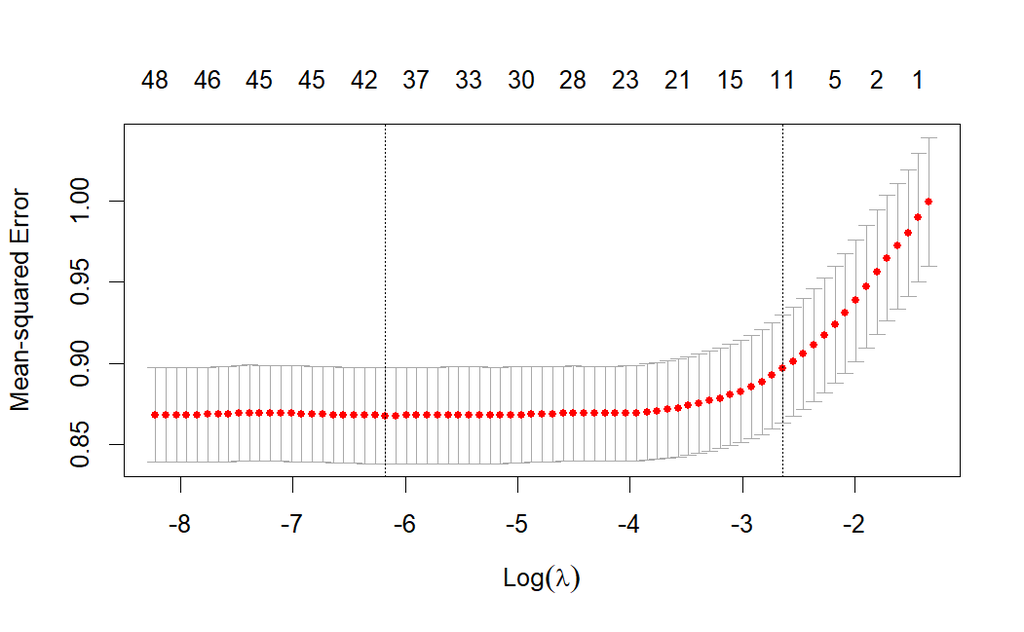

| Criteria | Lambda | MSE | SE | RMSE | Nonzero |
| --- | --- | --- | --- | --- | --- |
| min | 0.002 | 0.868 | 0.030 | 0.931 | 41 |
| 1se | 0.071 | 0.897 | 0.033 | 0.947 | 12 |

### Fit statistics

| Sample | Lambda | MSE | RMSE | MAE |
| --- | --- | --- | --- | --- |
| training | min | 0.843 | 0.918 | 0.653 |
| training | 1se | 0.890 | 0.943 | 0.672 |
| test | min | 0.834 | 0.913 | 0.633 |
| test | 1se | 0.834 | 0.913 | 0.633 |

### Plot predictions

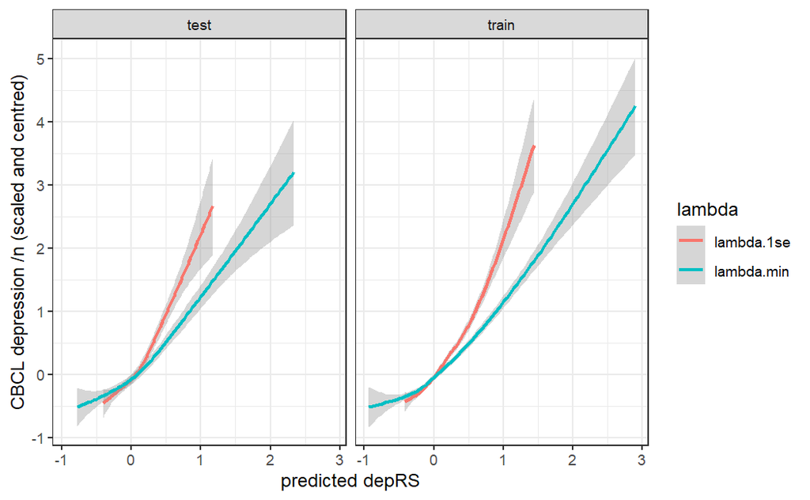

## CBCL internalising subscale

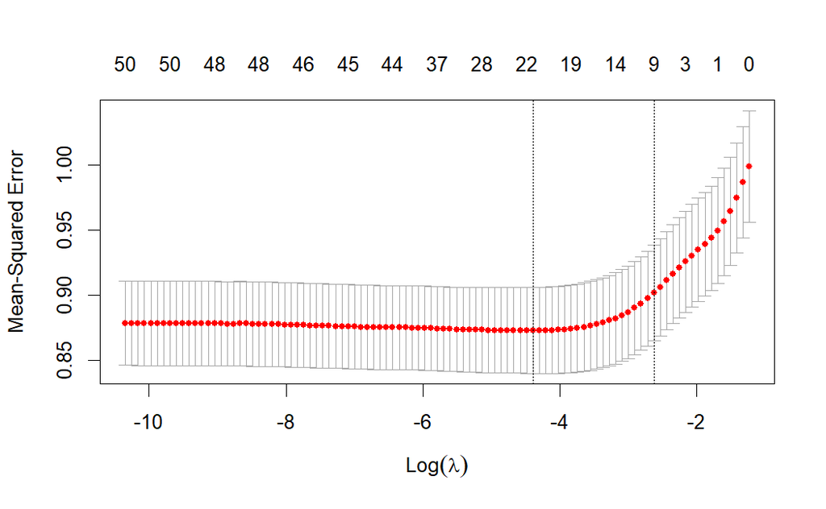

[output not shown]

### Fit statistics

| Sample | Lambda | MSE | RMSE | MAE |
| --- | --- | --- | --- | --- |
| training | min | 0.860 | 0.927 | 0.671 |
| training | 1se | 0.897 | 0.947 | 0.687 |
| test | min | 0.843 | 0.918 | 0.633 |
| test | 1se | 0.843 | 0.918 | 0.633 |

### Plot predictions

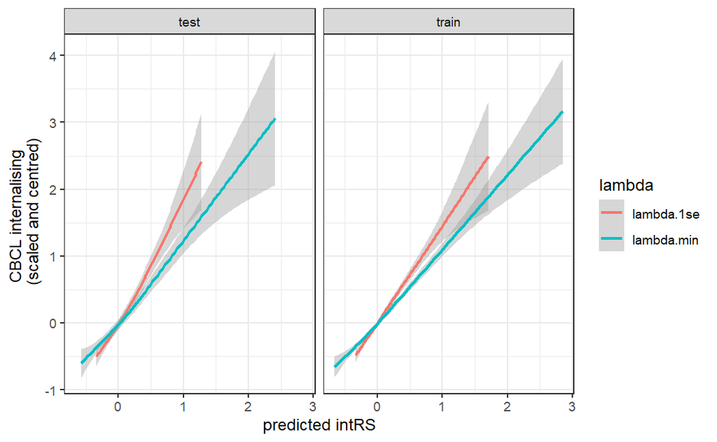

## Non-zero coefficients

beta.min = coefficients for lambda value that produces minimum mean cross-validated error. beta.1se = coefficients for lambda value that produces the most regularized model while keeping the cross-validated error within one standard error of the minimum.

| predictor | dep_beta.min | dep_beta.1se | int_beta.min | int_beta.1se |
| --- | --- | --- | --- | --- |
| (Intercept) | -2.328 | -0.426 | -1.937 | -0.396 |
| tlfb_use_days | 0.087 | 0.000 | 0.016 | 0.000 |
| weightcontrol_ksads | 0.000 | 0.141 | 0.298 | 0.073 |
| witness_comm_violence | -0.113 | 0.000 | 0.000 | 0.000 |
| death_loved_one | 0.000 | 0.000 | 0.033 | 0.000 |
| witness_dv | 0.107 | 0.000 | 0.078 | 0.000 |
| s_abuse | 0.532 | 0.054 | 0.681 | 0.274 |
| p_abuse | 1.228 | 0.000 | 0.468 | 0.000 |
| emot_abuse | 0.240 | 0.000 | 0.035 | 0.000 |
| serious_accident | 0.096 | 0.000 | 0.081 | 0.000 |
| bkfs_fruit | -0.018 | 0.000 | -0.002 | 0.000 |
| bkfs_veg | -0.054 | 0.000 | 0.000 | 0.000 |
| sleep_hrs | 0.017 | 0.113 | 0.000 | 0.000 |
| bmi | 0.017 | 0.000 | 0.024 | 0.000 |
| needed_food | 0.210 | 0.004 | 0.112 | 0.000 |
| income | 0.000 | 0.000 | 0.000 | 0.000 |
| parent_ed | 0.000 | 0.000 | 0.000 | 0.000 |
| birthsex | 0.000 | 0.000 | 0.000 | 0.000 |
| comm_safety | -0.085 | 0.000 | -0.036 | 0.000 |
| discrimination | 0.007 | 0.000 | 0.000 | 0.000 |
| days_active | -0.021 | 0.000 | -0.010 | 0.000 |
| bully_relational | 0.126 | 0.024 | 0.053 | 0.017 |
| bully_reputational | 0.038 | 0.035 | 0.040 | 0.039 |
| bully_overt | -0.045 | 0.000 | 0.000 | 0.000 |
| chronotype | -0.006 | 0.000 | 0.000 | 0.000 |
| life_events | 0.159 | 0.145 | 0.201 | 0.191 |
| agemths | 0.000 | 0.000 | 0.000 | 0.000 |
| tlfb_use_days_sex | -0.038 | 0.000 | 0.000 | 0.000 |
| weightcontrol_ksads_sex | 0.280 | 0.000 | 0.000 | 0.000 |
| witness_comm_violence_sex | 0.000 | 0.000 | 0.000 | 0.000 |
| death_loved_one_sex | 0.000 | 0.000 | 0.000 | 0.000 |
| witness_dv_sex | -0.033 | 0.000 | 0.000 | 0.000 |
| s_abuse_sex | 0.000 | 0.000 | 0.000 | 0.000 |
| p_abuse_sex | -0.440 | 0.000 | 0.000 | 0.000 |
| emot_abuse_sex | 0.000 | 0.000 | 0.000 | 0.000 |
| serious_accident_sex | 0.000 | 0.000 | 0.000 | 0.000 |
| bkfs_fruit_sex | -0.003 | 0.000 | 0.000 | 0.000 |
| bkfs_veg_sex | 0.018 | 0.000 | 0.000 | 0.000 |
| sleep_hrs_sex | 0.098 | 0.000 | 0.036 | 0.015 |
| bmi_sex | 0.005 | 0.000 | 0.000 | 0.000 |
| needed_food_sex | -0.012 | 0.000 | 0.000 | 0.000 |
| income_sex | 0.015 | 0.000 | 0.000 | 0.000 |
| parent_ed_sex | -0.007 | 0.000 | 0.000 | 0.000 |
| comm_safety_sex | 0.042 | 0.000 | 0.000 | 0.000 |
| discrimination_sex | -0.017 | 0.000 | 0.000 | 0.000 |
| days_active_sex | -0.026 | -0.002 | -0.021 | 0.000 |
| bully_relational_sex | -0.039 | 0.000 | 0.000 | 0.000 |
| bully_reputational_sex | 0.007 | 0.001 | 0.000 | 0.000 |
| bully_overt_sex | 0.073 | 0.021 | 0.029 | 0.006 |
| chronotype_sex | 0.013 | 0.000 | 0.000 | 0.000 |
| life_events_sex | 0.029 | 0.020 | 0.020 | 0.012 |
| agemths_sex | 0.015 | 0.000 | 0.007 | 0.000 |

### beta.min

|  | preds | beta.min | beta.1se | out |
| --- | --- | --- | --- | --- |
| 81 | p_abuse | 1.2276219 | 0.0000000 | CBCL_depression |
| 7 | s_abuse | 0.6814403 | 0.2743569 | CBCL_internalising |
| 71 | s_abuse | 0.5321588 | 0.0544529 | CBCL_depression |
| 8 | p_abuse | 0.4682201 | 0.0000000 | CBCL_internalising |
| 3 | weightcontrol_ksads | 0.2982350 | 0.0733031 | CBCL_internalising |
| 291 | weightcontrol_ksads_sex | 0.2802258 | 0.0000000 | CBCL_depression |
| 91 | emot_abuse | 0.2404456 | 0.0000000 | CBCL_depression |
| 151 | needed_food | 0.2096736 | 0.0040018 | CBCL_depression |
| 26 | life_events | 0.2010695 | 0.1909365 | CBCL_internalising |
| 261 | life_events | 0.1586992 | 0.1451066 | CBCL_depression |
| 221 | bully_relational | 0.1261148 | 0.0239258 | CBCL_depression |
| 15 | needed_food | 0.1122700 | 0.0000000 | CBCL_internalising |
| 61 | witness_dv | 0.1073499 | 0.0000000 | CBCL_depression |
| 391 | sleep_hrs_sex | 0.0978990 | 0.0000000 | CBCL_depression |
| 101 | serious_accident | 0.0960089 | 0.0000000 | CBCL_depression |
| 210 | tlfb_use_days | 0.0867573 | 0.0000000 | CBCL_depression |
| 10 | serious_accident | 0.0806059 | 0.0000000 | CBCL_internalising |
| 6 | witness_dv | 0.0776661 | 0.0000000 | CBCL_internalising |
| 491 | bully_overt_sex | 0.0727257 | 0.0206304 | CBCL_depression |
| 22 | bully_relational | 0.0533476 | 0.0169944 | CBCL_internalising |
| 441 | comm_safety_sex | 0.0421954 | 0.0000000 | CBCL_depression |
| 23 | bully_reputational | 0.0395138 | 0.0385518 | CBCL_internalising |
| 231 | bully_reputational | 0.0382824 | 0.0348912 | CBCL_depression |
| 39 | sleep_hrs_sex | 0.0358382 | 0.0147340 | CBCL_internalising |
| 9 | emot_abuse | 0.0351173 | 0.0000000 | CBCL_internalising |
| 5 | death_loved_one | 0.0325337 | 0.0000000 | CBCL_internalising |
| 511 | life_events_sex | 0.0290786 | 0.0197095 | CBCL_depression |
| 49 | bully_overt_sex | 0.0285486 | 0.0056496 | CBCL_internalising |
| 14 | bmi | 0.0243251 | 0.0000000 | CBCL_internalising |
| 51 | life_events_sex | 0.0202750 | 0.0118710 | CBCL_internalising |
| 381 | bkfs_veg_sex | 0.0178522 | 0.0000000 | CBCL_depression |
| 131 | sleep_hrs | 0.0174599 | 0.1128492 | CBCL_depression |
| 141 | bmi | 0.0167644 | 0.0000000 | CBCL_depression |
| 2 | tlfb_use_days | 0.0160237 | 0.0000000 | CBCL_internalising |
| 421 | income_sex | 0.0154750 | 0.0000000 | CBCL_depression |
| 521 | agemths_sex | 0.0148480 | 0.0000000 | CBCL_depression |
| 501 | chronotype_sex | 0.0128374 | 0.0000000 | CBCL_depression |
| 481 | bully_reputational_sex | 0.0074460 | 0.0005907 | CBCL_depression |
| 201 | discrimination | 0.0068787 | 0.0000000 | CBCL_depression |
| 52 | agemths_sex | 0.0066205 | 0.0000000 | CBCL_internalising |
| 401 | bmi_sex | 0.0048668 | 0.0000000 | CBCL_depression |
| 11 | bkfs_fruit | -0.0017383 | 0.0000000 | CBCL_internalising |
| 371 | bkfs_fruit_sex | -0.0027704 | 0.0000000 | CBCL_depression |
| 251 | chronotype | -0.0063187 | 0.0000000 | CBCL_depression |
| 431 | parent_ed_sex | -0.0070975 | 0.0000000 | CBCL_depression |
| 21 | days_active | -0.0101582 | 0.0000000 | CBCL_internalising |
| 411 | needed_food_sex | -0.0124482 | 0.0000000 | CBCL_depression |
| 451 | discrimination_sex | -0.0167109 | 0.0000000 | CBCL_depression |
| 111 | bkfs_fruit | -0.0183182 | 0.0000000 | CBCL_depression |
| 46 | days_active_sex | -0.0211704 | 0.0000000 | CBCL_internalising |
| 211 | days_active | -0.0212686 | 0.0000000 | CBCL_depression |
| 461 | days_active_sex | -0.0258546 | -0.0024909 | CBCL_depression |
| 321 | witness_dv_sex | -0.0331003 | 0.0000000 | CBCL_depression |
| 19 | comm_safety | -0.0364765 | -0.0001772 | CBCL_internalising |
| 281 | tlfb_use_days_sex | -0.0378025 | 0.0000000 | CBCL_depression |
| 471 | bully_relational_sex | -0.0389641 | 0.0000000 | CBCL_depression |
| 241 | bully_overt | -0.0446291 | 0.0000000 | CBCL_depression |
| 121 | bkfs_veg | -0.0541013 | 0.0000000 | CBCL_depression |
| 191 | comm_safety | -0.0846049 | 0.0000000 | CBCL_depression |
| 410 | witness_comm_violence | -0.1132947 | 0.0000000 | CBCL_depression |
| 341 | p_abuse_sex | -0.4398287 | 0.0000000 | CBCL_depression |

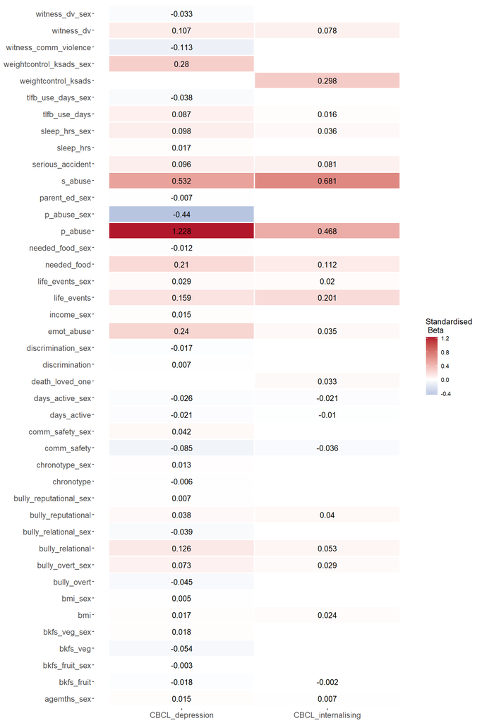

### beta.1se

|  | preds | beta.min | beta.1se | out |
| --- | --- | --- | --- | --- |
| 7 | s_abuse | 0.6814403 | 0.2743569 | CBCL_internalising |
| 26 | life_events | 0.2010695 | 0.1909365 | CBCL_internalising |
| 261 | life_events | 0.1586992 | 0.1451066 | CBCL_depression |
| 310 | weightcontrol_ksads | 0.0000000 | 0.1412523 | CBCL_depression |
| 131 | sleep_hrs | 0.0174599 | 0.1128492 | CBCL_depression |
| 3 | weightcontrol_ksads | 0.2982350 | 0.0733031 | CBCL_internalising |
| 71 | s_abuse | 0.5321588 | 0.0544529 | CBCL_depression |
| 23 | bully_reputational | 0.0395138 | 0.0385518 | CBCL_internalising |
| 231 | bully_reputational | 0.0382824 | 0.0348912 | CBCL_depression |
| 221 | bully_relational | 0.1261148 | 0.0239258 | CBCL_depression |
| 491 | bully_overt_sex | 0.0727257 | 0.0206304 | CBCL_depression |
| 511 | life_events_sex | 0.0290786 | 0.0197095 | CBCL_depression |
| 22 | bully_relational | 0.0533476 | 0.0169944 | CBCL_internalising |
| 39 | sleep_hrs_sex | 0.0358382 | 0.0147340 | CBCL_internalising |
| 51 | life_events_sex | 0.0202750 | 0.0118710 | CBCL_internalising |
| 49 | bully_overt_sex | 0.0285486 | 0.0056496 | CBCL_internalising |
| 151 | needed_food | 0.2096736 | 0.0040018 | CBCL_depression |
| 481 | bully_reputational_sex | 0.0074460 | 0.0005907 | CBCL_depression |
| 461 | days_active_sex | -0.0258546 | -0.0024909 | CBCL_depression |

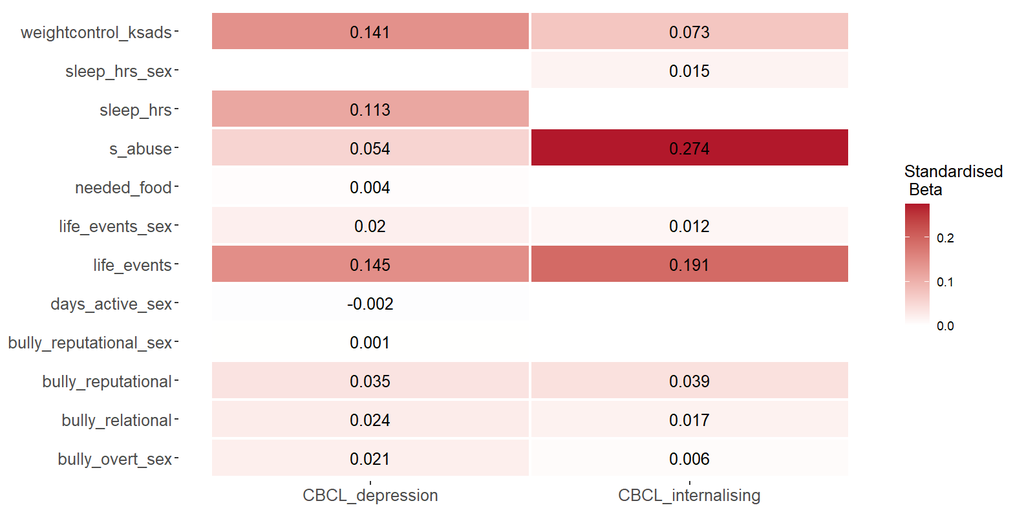